```python
from IPython.display import HTML
HTML('''
<script
    src="https://cdnjs.cloudflare.com/ajax/libs/jquery/2.0.3/jquery.min.js ">
</script>
<script>
code_show=true;
function code_toggle() {
 if (code_show){
 $('div.jp-CodeCell > div.jp-Cell-inputWrapper').hide();
 } else {
$('div.jp-CodeCell > div.jp-Cell-inputWrapper').show();
 }
 code_show = !code_show
}
$( document ).ready(code_toggle);
</script>
<form action="javascript:code_toggle()"><input type="submit"
    value="Click here to toggle on/off the raw code."></form>
''')
```

```python
from project_functions import *
```

[figure not shown]

# I. ABSTRACT

The board game industry has grown significantly, with a projected market size of $35 billion by 2030. This presents an opportunity for BoardGameGeek to enhance its website and offer personalized recommendations to users, potentially boosting user traffic. The team aims to address this by developing a hybrid recommendation system that considers factors like serendipity and relevance. This model combines latent-based collaborative filtering with content-based recommenders, ranking recommendations based on cosine similarity. Evaluation shows promising results, with the hybrid system (0.94 MAE and 0.8 nDCG) outperforming a NormalPredictor recommender (1.71 MAE) in mean absolute error and a content-based system (0.77 nDCG) in normalized discounted cumulative gain. However, the team suggests further exploration of hybrid models, feature expansion, expert consultation, and parameter optimization for improved accuracy.

# II. INTRODUCTION

In recent years, the board game industry has evolved into a billion-dollar sector, captivating enthusiasts worldwide and reaching a projected market size of $35 billion by 2030. This expansion has introduced a paradox of choice for users, with over 5,000 new board games released in 2020 alone, increasing the total available on BoardGameGeek (BGG) to more than 36,000. Among the platforms at the forefront of facilitating this growth, BGG stands out as a pivotal community hub. It offers an extensive database of board games, along with user-generated reviews, ratings, and forums, making it an invaluable resource for discovering and discussing board games.

The challenge of providing personalized board game recommendations on BGG is multifaceted. Users' preferences are as diverse as the board games themselves, ranging from thematic and strategic board games to casual party games. This diversity requires a recommendation system capable of understanding nuanced user preferences and suggesting games that not only match these preferences but also introduce users to new titles they are likely to enjoy. Additionally, the recommendation system must navigate the dynamic nature of user tastes, which evolve based on new experiences, trends, and community feedback.

To address this challenge, we propose the development and implementation of a hybrid recommender system. This system combines the strengths of content-based and collaborative filtering approaches to deliver personalized board game suggestions. The objective is twofold: to enhance user engagement on BGG by providing tailored recommendations and to streamline the discovery process, thereby increasing user satisfaction and potentially driving traffic to purchase platforms.

This paper presents our journey in designing, implementing, and evaluating a hybrid recommender system for BGG. By leveraging a rich dataset of user ratings and board game metadata, we aim to demonstrate the system's effectiveness in personalizing the board game discovery experience. Our research contributes to the broader field of recommender systems by showcasing the application of hybrid models in a niche yet rapidly expanding domain.

# III. PROJECT OBJECTIVES AND PURPOSE

## A. Problem Statement

The challenge of navigating the vast sea of options on the BGG website is exacerbated by the limitations of the company's existing recommendation systems which are which might recommend popular games that do not necessarily match a user's unique interests.

## B. Motivation

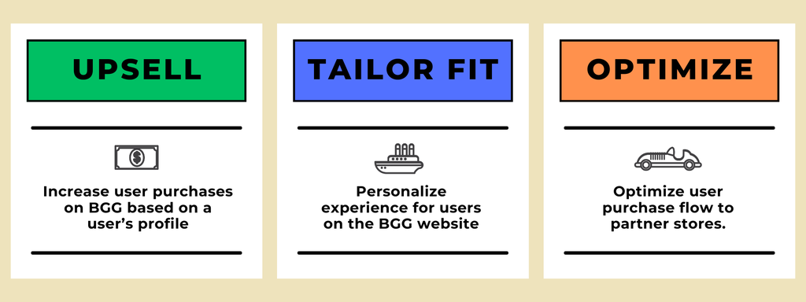

This study is driven by the understanding that a tailored approach to recommendation can significantly impact user satisfaction and engagement. In the context of BGG, where the diversity and number of available games can be overwhelming, a system that intelligently suggests games based on a user's unique preferences and past interactions has the potential to transform how users discover and engage with content.

Such a system not only serves to streamline the discovery process but also supports business objectives by increasing the likelihood of purchase conversions. By making game discovery more intuitive and aligned with individual tastes, users are more likely to be directed to purchase platforms. Additionally, this project is motivated by the broader goal of leveraging technology to foster a deeper connection between board game enthusiasts and the games that will most resonate with them. It represents an intersection of data science and user experience design, where the aim is to understand and predict user preferences in a way that feels natural and engaging.

# IV. PROJECT OVERVIEW

[figure not shown]

**Figure 1.** Project Overview

The project's ultimate aim is to generate board game suggestions for a specified user. To achieve this, the team will follow a six-step process beginning with collecting the required data. Data was extracted from Kaggle; however, it was segmented into various files. Consequently, the team needed to consolidate all of this into SQL for easy manipulation into its final form, ready to be input into the recommender system. The next step involves data preparation, which includes two components: sampling from the entire dataset to make it manageable for the model and utilizing one-hot encoding to represent categories in the item profile matrix. The outcome of this phase is the finalized dataset, suitable for both analysis and utilization by the model.

After completing the initial two steps, the team proceeds with exploratory data analysis, conducting a comprehensive evaluation of the dataset. This includes visualizations aimed at supporting the project objectives and methodology. Subsequently, the team constructs the pipeline for the meta-level hybrid recommender system. Finally, the team tests the model's accuracy and generates results. Despite the progress, there are limitations to this project. Hence, the team will propose topics for future investigation (See Figure 1).

**Table 1.** Project Pipeline

|  | Step | Detailed Description |
| --- | --- | --- |
| `1` | Data Collection | The dataset utilized for the project was sourced from Kaggle and comprises diverse information on board games available on the BoardGameGeek (BGG) website. This information includes ratings, board gam… |
| `2` | Data Preparation | This project segment consists of two components. Firstly, sampling from the original dataset, which includes around 19 million user ratings, was performed to reduce it to approximately 10,000 items an… |
| `3` | Data Exploration | In this section, the team utilized data visualization techniques to extract insights from the prepared dataset. Primarily, bar graphs and histograms were employed as they align with the information th… |
| `4` | Pipeline Building | The primary objective of the project is to provide board game recommendations to users, for which the team must establish the pipeline for the recommender system. Specifically, the team chose to const… |
| `5` | Results and Discussion | After constructing the pipeline, the model is tested, and recommendations can now be generated, which is the objective of this section. To evaluate the accuracy of the results, the mean absolute error… |
| `6` | Recommendations | The team acknowledges constraints that may have influenced the results. These limitations include the omission of other board game features, the team's limited industry expertise, and the absence of h… |

The project pipeline offers a comprehensive overview of the team's approach throughout the entire project, encompassing tasks from data collection to proposing future research directions. It provides a detailed breakdown of each stage, including sub-steps, to ensure a comprehensive understanding of the process (Refer to Table 1 for specifics).

# V. DATA COLLECTION

## A. Data Source

Data was extracted from Kaggle and compiled into an SQLite database for efficient manipulation. The dataset encompasses user profiles, game ratings and game genres, providing a comprehensive foundation for our analysis and recommendation algorithm development.

## B. Metadata and Data Descriptions

**Table 2.** Features

| Feature Name | Feature Description | Sample Record | Data Type |
| --- | --- | --- | --- |
| UserID | A unique identifier for each user on the BGG platform. This allows for the analysis of individual and collective rating patterns and preferences. | 10,000 | integer |
| ItemID | A unique identification number assigned to each board game, enabling the tracking of game popularity and user interactions. | 9,481 | integer |
| Ratings | Numerical values provided by users, reflecting their appreciation and engagement with each board game. Ratings are crucial for understanding user preferences and for the collaborative filtering aspect… | 1 million user | integer |
| Game Genres | Categorical data representing the various types of board games, such as card games, war games, fantasy, party games, and more. Genre information is vital for the content-based component of the recomme… | 83 unique categories | string |

The core of our hybrid recommender system relies on a thorough dataset obtained from BoardGameGeek through Kaggle. This dataset plays a crucial role in grasping user preferences and enabling personalized board game recommendations. Organized into an SQLite database, this dataset forms a robust basis for our analysis and recommendation algorithm development. It encompasses around 1 million user ratings for nearly 10,000 distinct board games, spanning across 83 different genres. This comprehensive dataset provides valuable insights into the preferences and interactions within the BGG community (see Table 2).

# VI. DATA PRE-PROCESSING

## A. Load Data

The first step in our approach is to load the dataset from an SQLite database. This step is crucial as it lays the foundation for the entire data preprocessing process. The data comes from different sources and needs to be combined into one structure for analysis and preprocessing. The dataset, mainly from BoardGameGeek, includes a wide range of board games, user ratings, and metadata, providing a strong basis for building a sophisticated recommendation system.

```python
conn = create_sqlite_db()
```

```python
create_pickle_files(conn)
```

## B. Data Pre-processing

Under Data preparation, the team executed the following steps:

**Sample Data:**

- The team sampled nearly 19 million ratings from the dataset.
- They managed to reduce the dataset to approximately 10,000 users and 10,000 items using the pandas method called sample.

**Create a Ratings Matrix and Item Profile Matrix:**

- With the selected users and items, creating a matrix where rows correspond to users, columns correspond to items, and the cells contain the rating that a user has given to an item.
- For users or items that do not have a rating, choosing to fill those cells with zeros or a placeholder value.

**Apply One-Hot Encoding:**

- One-hot encoding is typically applied to categorical variables to convert them into a binary vector. In the context of a recommendation system, applying one-hot encoding to item or user features (like genres for movies or categories for products).

```python
df_item_profile = pd.read_pickle('df_item_profile.pkl')
```

```python
df_reviews = pd.read_pickle('reviews.pkl')
```

# VII. EXPLORATORY DATA ANALYSIS

## A. Top Available Board Games on BGG

```python
df = pd.read_sql(
    """
    SELECT
        ID,
        COUNT(rating) as count_r
    FROM
        games_info g
    JOIN
        reviews r USING(ID)
    GROUP BY
        1
    """,
    conn
)
df2 = pd.read_sql(
    """
    SELECT
        ID,
        "primary",
        boardgamecategory
    FROM
        games_info g
    """,
    conn
)
mlb = MultiLabelBinarizer()
pattern = r'["\']([^"\']+)["\']'
categ = df2['boardgamecategory'].str.extractall(pattern).reset_index()
df2['category'] = categ.groupby('level_0')[0].apply(
        ', '.join
    ).str.split(', ')
df2 = df2.dropna(subset=['category'])
df_encoded = mlb.fit_transform(df2['category'])
df_encoded = pd.DataFrame(df_encoded,
                          columns=mlb.classes_,
                          index=df2['id'])
df2 = df2.set_index('id')
df_item_categ = pd.concat([df2, df_encoded.iloc[:, 1:]], axis=1)
df_item_categ = df_item_categ.drop(
    columns=['boardgamecategory', 'category']
)
```

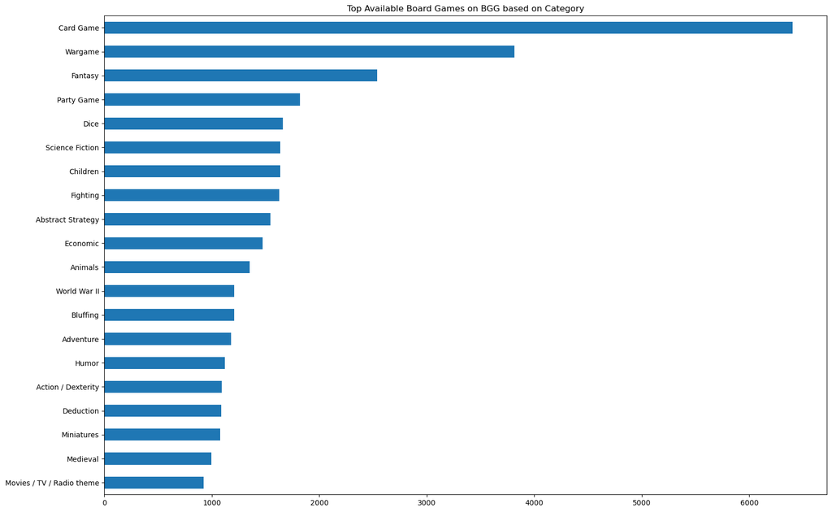

```python
df_item_categ.iloc[:, 1:].sum().sort_values(
    ascending=False
).head(20)[::-1].plot.barh(figsize=(18, 12))
plt.title('Top Available Board Games on BGG based on Category')
plt.show()
```

**Figure 2.** Top Board Game Categories

**Most Popular Themes**: The most populated categories are "Card Game" and "Wargame," indicating a strong community interest or a larger number of these types of games available on BGG (Fig. 2).

**Focused Interests**: The data implies that BGG users may have specific interests, favoring traditional gaming themes like "Card Game" and "Wargame" over those tied to other media. This might reflect a community preference for classic or original game mechanics and themes.

**Community Niche**: The BGG community may prefer games that offer unique experiences not found in other media. This could explain why games without a movie or TV theme are more numerous, as the community might value originality and gaming as a standalone hobby.

## B. Number of Ratings vs. Number of Users

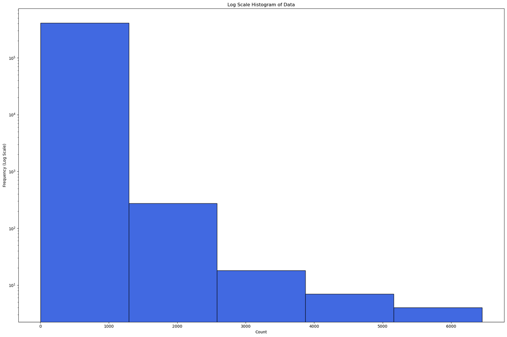

```python
user_df = pd.read_sql(
    """
    SELECT
        user,
        COUNT(rating) as count_r
    FROM
        games_info g
    JOIN
        reviews r USING(ID)
    GROUP BY
        1
    """,
    conn
)
user_df = user_df.set_index('user')
plt.figure(figsize=(18, 12))
plt.hist(user_df['count_r'],
         bins=5,
         color='royalblue',
         edgecolor='black',
         log=True)
plt.title('Log Scale Histogram of Data')
plt.xlabel('Count')
plt.ylabel('Frequency (Log Scale)')
plt.tight_layout()

plt.show()
```

**Figure 3.** User Distribution based on Total No. of Items Rated

**User Engagement Levels**: The vast majority of users engage minimally (see Fig 3). This group likely represents casual users or new members of BGG who have interacted with only a small fraction of the board games available.

**Active Users Segment**: There is a noticeable drop-off as we move to higher rating counts. Users who rate between 1,291 and 2,582 items are significantly fewer. This trend continues with each subsequent range, illustrating a common pattern in online communities where a small subset of users accounts for a large portion of the engagement.

**Long Tail Distribution**: A small core of highly active users rate many items, but there's a long tail of users with few ratings. Targeting the long tail could increase overall community activity and game exploration.

## C. Generalized Insights

While certain themes are more numerous on BoardGameGeek, users may not be rating them extensively, implying a lack of exploration across the full spectrum of available games.

**Unexplored Variety**: Although "Card Game" and "Wargame" themes are prevalent, the fact that users have rated relatively few items suggests a large portion of the board game universe remains largely unexplored by the majority of users on BGG.

**Opportunity for Discover**: The diversity of board game themes presents an opportunity for users to discover and explore new game genres beyond their usual preferences, potentially leading to a broader gaming experience.

**Potential Market Gaps**: The scarcity of "Movies / TV / Radio theme" games might represent a potential gap in the market. If these types of games are popular outside BGG, there could be an opportunity for publishers or creators to introduce more of them to the site.

**Community Engagement**: The indication that many users have few rated items might signal an opportunity for BGG and game creators to engage the community in new ways, encouraging them to explore and rate a more diverse range of games.

**Tailored Recommendations**: BGG could potentially leverage this information to tailor recommendations for users, nudging them to try and rate games outside their typical genres, which could help games in less-rated categories gain more visibility.

# VIII. METHOD IMPLEMENTATION

# **METHODOLOGY**

[figure not shown]

**Figure 4.** Meta-level Hybrid Pipeline

The team opted to use a meta-level hybrid recommender system (see Fig 4) as it is one of the most effective and straightforward models to use. Other hybrid recommender systems were considered, such as weighted and switch. However, the uncertainty in setting weights and thresholds needed to combine recommender systems posed an issue that could affect results. One of the benefits of the meta-level hybrid is that you simply use two recommenders in a sequential manner. The meta-level hybrid recommender system works as follows: the output of one recommender system is used as an input in the other. The result combines the inherent benefits of each system used. In the case of the study, a Latent factor-based collaborative filtering recommender system was the initial model used, and its output was inserted into a content-based recommender system. The former outputs recommendations that are more serendipitous, while the latter outputs more relevant results that are aligned with the genre that the user is mostly interacting with (BluePi, n.d.).

To discuss the pipeline in detail, it starts by running a latent factor-based recommender system on the created user-item rating matrix, which is highly sparse data because users, on average, only rate a small number of items compared to the total number of board games available. The output of the initial recommender system is a highly dense matrix since those items not rated by users are estimated by decomposing the user-item matrix into its own user matrix and item matrix. These are then multiplied together to complete the user-item matrix, synthesizing ratings for unrated items.

The subsequent step involves utilizing the ratings from the initial recommender system, both original and estimated, as input for the other recommendation process, which is a content-based recommender system. The resulting output will be the user's profile to be generated board game suggestions for.

Based on the user's profile, the team retrieved the most similar board games by way of cosine similarity. Logarithmic scaling was used to ensure that highly available genres do not come up as recommendations. In this case, the team wants to consider niche categories, items that do not appear as often among the total number of available board games. The final step of the methodology involves ranking the items accordingly, which serves as the recommendations to the user.

## Latent Factor-based Collaborative Filtering

A Latent factor Model is a type of Collaborative-Filtering recommender system that uses Matrix Factorization to decompose a large and sparse matrix into smaller and denser matrices. Both users and items are projected into a joint latent factor space and uses pattern recognition to fill in the gaps and complete the user-item interactions (Fang, 2021).

```python
df_sampled = df_reviews.sample(n=1_000_000, random_state=24)
sampled_items = df_sampled['item_id'].unique().tolist()
algo = lf_training(df_sampled)
users = ['hipshot']
results = {
    user: get_user_predictions(user, algo, df_sampled)
    for user in users
}
```

### Using Surprise Package (SVD)

`Surprise` is a python library purposely built to create and analyze recommender systems with explicit rating data (Hug, 2022). This package provides built-in functions for various algorithms used in recommender systems such as baseline algorithms, neighborhood methods, and matrix factorization-based methods.

Singular Value Decomposition, `SVD`, was used to implement the Latent Factor-based Collaborative Filtering. SVD is a matrix factorization-based method popularized by Simon Funk during the Netflix Prize. Predictions are made using the following formula:

\begin{equation} \hat{r}_{ui} = \mu + b_u + b_i + q_i^T p_u \end{equation}

To estimate the unknown ratings, the following regularized squared error is minimized:

\begin{equation} \sum_{r_{ui} \in R_{train}} (r_{ui} - \hat{r}_{ui})^2 + \lambda(\lvert\lvert b_i\rvert\rvert^2 + \lvert\lvert b_u\rvert\rvert^2 + \lvert\lvert q_i\rvert\rvert^2 + \lvert\lvert p_u\rvert\rvert^2) \end{equation}

Minimization of the regularized squared error is done using Stochastic Gradient Descent.

### Testing using MAE

Mean Absolute Error (MAE) was used to validate the estimated ratings of our model. MAE measures how far off the predictions are from a set of original ratings of the user. A lower MAE is needed to ensure that minimal errors are propagated when using the results of the LF Recommender System as inputs to the Content-based Recommender System.

MAE score of the SVD factorization will be compared to another algorithm in the Surprise package, `NormalPredictor`. The NormalPredictor randomly generates a point based on the distribution of the training set, assumed to be normal, as the prediction of the rating. This algorithm predicts randomly using the distribution of the training set generated using Maximum Likelihood Estimation.

## Content-based Recommender System (through Unary Aggregation)

The results of the Latent Factor-based recommender system was used as an input of the Content-based Recommender System.

Content-based recommender systems considers actual content in estimating unrated items of a user. However, this does not consider the ratings of other users, only the target user's ratings. Using the target user's ratings, a user profile is computed through aggregation of the item profiles. The item profiles that are considered for the user profile are those that have a rating that is above the mean of the user's ratings.

Our meta hybrid recommender system modifies the above mentioned aggregation by including item profiles not yet rated by the user. To consider these item profiles, our model used the estimated ratings from the output of the Latent Factor-based recommender system. Ratings were still compared to the original user rating mean, so as to capture only item profiles that are above the aforementioned values.

Once the modified user profile is established, recommended items were retrieved by calculating the cosine similarity between the user profile and each of the item profiles of the unrated items. Cosine similarity is described using the following equation:

\begin{equation} \text{cosine similarity} = \frac{\sum_{i=1}^{n} A_i B_i}{\sqrt{\sum_{i=1}^{n} A_i^2} \sqrt{\sum_{i=1}^{n} B_i^2}} \end{equation}

```python
df_raw_item_profile = pd.read_pickle('df_raw_item.pkl')
recommendations = get_recommendations_users(
    results,
    df_raw_item_profile,
    df_item_profile,
    sampled_items,
    L=10
)
```

### Testing using NDCG

To evaluate the ranked recommendations of the meta-hybrid recommender system, Discounted Cumulative Gain (DCG) was used. DCG represents the importance of highly relevant items ranking higher on the list (Efimov, 2023). DCG is computed using the following formula:

\begin{equation} \text{DCG} = \frac{1}{m} \sum_{u=1}^m \sum_{j \in I_u, v_j \leq L} \frac{2^{r_{uj}} - 1}{\log_2 (v_j + 1)} \end{equation}

The Idealized Discounted Cumulative Gain represent the DCG when the order of ranking matches the ground truth. Combined, the Normalized Discounted Cumulative Gain (NDCG) is the DCG normalized by the maximum DCG value given the returned results.

NDCG score of the meta-hybrid recommender system was compared to the NDCG when using only the content-based recommender system. This should highlight the difference in the relevance of the returned results with the help of the modified user profile.

# IX. RESULTS AND DISCUSSION

## Latent Factor-based Collaborative Filtering Validation using MAE

The functions `normal_pred` and `cross_validate_lf` were used to cross validate the NormalPredictor and SVD Algorithms, respectively. Both functions use the `cross_validate` function of the Surprise package to create 5 different folds of the dataset. MAE is tested for each fold and the mean was used to compare the two algorithms.

**Table 3.** MAE Results

```python
normal_results = normal_pred(df_reviews)
cv_results = cross_validate_lf(df_reviews)
normal_mae_results = normal_results['test_mae'].tolist()
normal_mae_results.append(normal_results['test_mae'].mean())
mae_results = cv_results['test_mae'].tolist()
mae_results.append(cv_results['test_mae'].mean())
data = pd.DataFrame([normal_mae_results, mae_results],
                    index=['NormalPredictor', 'SVD'],
                    columns=[1, 2, 3, 4, 5, 'Mean'])
html = data.to_html(classes='table table-striped')
display(HTML(f"<div style='text-align: center'>{html}</div>"))
```

|  | 1 | 2 | 3 | 4 | 5 | Mean |
| --- | --- | --- | --- | --- | --- | --- |
| NormalPredictor | 1.708868 | 1.707328 | 1.703672 | 1.702855 | 1.706023 | 1.705749 |
| SVD | 0.945173 | 0.941391 | 0.947502 | 0.943951 | 0.944388 | 0.944481 |

Table 3 shows that on average, the SVD algorithm performs better over the Normal Predictor by about 0.76. SVD has an MAE of 0.944, our roughly less than $\pm$1 error for the estimated ratings. With this result, we show that the input values for the modified user profile in the content-based recommender system is close to the true value and minimal error will propagate.

## Content-based Validation using NDCG

The functions `get_ndcg_cb` and `get_hybrid_ndcg` were used to calculate and cross validate the NDCG score of Content-based only and Meta Hybrid Recommendations, respectively. Both functions cross validate by randomly removing `k` items from the originally rated items of a random user. These ratings were then estimated and ranked to compute for NDCG. This is done over 10 iterations of randomly chosen users.

**Table 4.** NDCG Results

```python
ndcg_cb = []
ndcg_hybrid = []
for L in [5, 10, 15]:
    ndcg_cb.append(get_ndcg_cb(df_reviews, df_item_profile, L))
    ndcg_hybrid.append(get_hybrid_ndcg(df_sampled, df_item_profile, algo, L))



data = pd.DataFrame([ndcg_cb, ndcg_hybrid],
                    index=['Content-based Only', 'Meta-Hybrid'],
                    columns=[5, 10, 15])
html = data.to_html(classes='table table-striped')
display(HTML(f"<div style='text-align: center'>{html}</div>"))
```

|  | 5 | 10 | 15 |
| --- | --- | --- | --- |
| Content-based Only | 0.779595 | 0.753209 | 0.738884 |
| Meta-Hybrid | 0.804554 | 0.804563 | 0.796326 |

Table 4 shows that at higher values of k, the meta-hybrid model becomes more robust. It remains a steady NDCG score even at higher k. At k=5, we see the NDCG of our model is at 0.80, which was an improvement over the 0.78 score using Content-based only.

## Meta-level Hybrid Recommender System Results

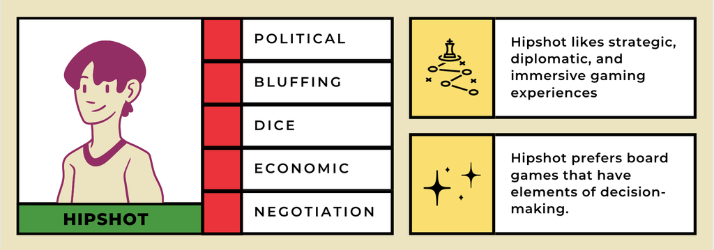

Prior to making predictions, it is crucial to profile the user to gain a better understanding of whether their preferences align with the recommendations. For the user tested in this case, hipshot, preferences lean towards categories such as political, bluffing, dice, economic, and negotiation. These top-ranking categories are determined from the weighted score of all features, where the weights are based on the user's actual and synthetic ratings across various board games.

In summary, the user prefers board games that entail strategy and diplomacy. Additionally, they seek immersive experiences where players become invested in the characters within the games. Lastly, the preferences indicate a penchant for decision-making aspects. Hipshot enjoys games that stimulate thought, whether it's determining the next move in the board game or selecting a path to follow.

**Table 5.** User Profile and Recommended Board Game Results

```python
for user, user_dict in recommendations.items():
    print(user, "'s Top 5 Features in User Profile'")
    print(user_dict['profile'].sort_values(ascending=False).head())
    print('Top 5 Recommendations')
    display(user_dict['reco'].head())
```

```
hipshot 's Top 5 Features in User Profile'
Political      0.708055
Bluffing       0.552023
Dice           0.490037
Economic       0.471598
Negotiation    0.451414
dtype: float64
Top 5 Recommendations
```

| id | primary | Abstract Strategy | Action / Dexterity | Adventure | Age of Reason | American Civil War | American Indian Wars | American Revolutionary War | American West | Ancient | ... | Travel | Trivia | Video Game Theme | Vietnam War | Wargame | Word Game | World War I | World War II | Zombies | rating |
| --- | --- | --- | --- | --- | --- | --- | --- | --- | --- | --- | --- | --- | --- | --- | --- | --- | --- | --- | --- | --- | --- |
| 1873 | Babylon 5 Component Game System: Core Sets | 0 | 0 | 0 | 0 | 0 | 0 | 0 | 0 | 0 | ... | 0 | 0 | 0 | 0 | 1 | 0 | 0 | 0 | 0 | 5.390110 |
| 205716 | New Angeles | 0 | 0 | 0 | 0 | 0 | 0 | 0 | 0 | 0 | ... | 0 | 0 | 0 | 0 | 0 | 0 | 0 | 0 | 0 | 6.377345 |
| 192777 | Junta: Las Cartas | 0 | 0 | 0 | 0 | 0 | 0 | 0 | 0 | 0 | ... | 0 | 0 | 0 | 0 | 0 | 0 | 0 | 0 | 0 | 5.308375 |
| 6472 | A Game of Thrones | 0 | 0 | 0 | 0 | 0 | 0 | 0 | 0 | 0 | ... | 0 | 0 | 0 | 0 | 1 | 0 | 0 | 0 | 0 | 5.580164 |
| 103343 | A Game of Thrones: The Board Game (Second Edit... | 0 | 0 | 0 | 0 | 0 | 0 | 0 | 0 | 0 | ... | 0 | 0 | 0 | 0 | 1 | 0 | 0 | 0 | 0 | 7.237790 |

5 rows × 85 columns

[figure not shown]

It can be seen that the results (see Table 5) are more relevant than serendipitous, a sentiment confirmed by one of the board game enthusiasts consulted by the team. The individual consulted, named Joshua San Juan, is a 15-year board game geek and enthusiast. He went on to say that the five recommended games - Babylon 5, New Angeles, Junta, and Game of Thrones - emphasize diplomacy, negotiation, and strategy. Furthermore, they involve complex player interactions and political maneuvering. Comparing these descriptions to the preferences, they are not far off and capture what the user actually wants.

# X. CONCLUSION

The quest to refine and personalize the user experience on BoardGameGeek (BGG) through advanced recommendation systems has culminated in the development of a meta-level hybrid recommender system detailed in this paper. Our system's innovative approach, which merges the strengths of latent-based collaborative filtering with content-based recommenders, has effectively addresses the dual objectives of matching users' unique interests and encouraging serendipitous discovery.

As an example, the team provided board game recommendations to Hipshot, a user on BoardGameGeek. Through analysis, it was observed that Hipshot's preferences leaned towards strategy, diplomacy, immersiveness, and decision-making. Profiling the user, the model suggests a blend of relevance and serendipity in recommendations, with a slightly stronger emphasis on relevance, as advised by a domain expert. Accordingly, the model proposes Babylon 5, New Angeles, Junta, and the Game of Thrones board games, aligning well with the user's preferences.

The industry expert further confirmed that the user recommendations were accurate, reflecting how they typically select games. While this is just one satisfied expert, their positive feedback suggests that others may also find the recommender system satisfactory. Thus, we can conclude that the team's recommender system has the potential to personalize board game suggestions, ultimately enhancing profits and streamlining the user purchase process.

# XI. LIMITATIONS AND RECOMMENDATIONS

## A. Limitations

The team acknowledges several limiting factors to the study. Those listed are used to guide the team in determining which topics or changes can be further explored by future researchers.

1. **Scalability**: As the number of users and items grows, maintaining the performance and responsiveness of the recommendation system can become increasingly challenging.
2. **Use of Features**: The team omitted certain features available on the BoardGameGeek website. Specifically, they only included board game categories as features for the item profile matrix.
3. **Limited Expertise on Board Games**: Members of the team were not thoroughly acquainted with the various board games available on the BGG website. Consequently, it was challenging to ascertain whether the recommendations genuinely aligned with user preferences. Additionally, the team chose to consult only a limited number of enthusiasts within close proximity.
4. **Lack of Temporal Aspect to the Study**: The study does not account for changes in user preferences over time. Additionally, the number of ratings for older board games might be higher compared to those recently released.
5. **Absence of Hyperparameter Tuning**: The team did not further optimize the recommender systems. The only adjustment made was to the parameters of the content-based recommender system, with only one parameter being modified.

## B. Recommendations

# XII. REFERENCE

BluePi. (n.d.). Demystifying Hybrid Recommender Systems and their Use Cases. Retrieved from: https://bluepiit.com/hybrid-recommender-systems/.

Efimov, V. (2023). Comprehensive Guide to Ranking Evaluation Metrics - Towards Data Science. Towards Data Science. Retrieved from https://towardsdatascience.com/comprehensive-guide-to-ranking-evaluation-metrics-7d10382c1025

Elteren, J. V. (2022, March). BoardGameGeek Reviews. https://www.kaggle.com/datasets/jvanelteren/boardgamegeek-reviews

Fang, J., Zhang, X., Hu, Y., Xu, Y., Yang, M., & Liu, J. (2021, January). Probabilistic Latent Factor Model for Collaborative Filtering with Bayesian Inference. In 2020 25th International Conference on Pattern Recognition (ICPR) (pp. 73-80). IEEE.

Hug, N. (2022, August 29). Home. Retrieved from https://surpriselib.com

Matrix Factorization-based algorithms — Surprise 1 documentation. (2022, September 24). Retrieved from https://surprise.readthedocs.io/en/stable/matrix_factorization.html#surprise.prediction_algorithms.matrix_factorization.SVD